# Dose-Response Experiment with Bayesian method

Shejuty Devnath

At first lets recall what we have so far from Biossay Experiment, Dose-Response Logistic Model, ( It is from BDA3, chapter 3) Following is the code of regenerating the data and the models:

```r
# Dose in log(g/ml)
X = c(-0.86,-0.30,-0.05,0.73)
N = rep(5,4)
# Deaths
Y = c(0,1,3,5)
# Table 3.1
knitr::kable(cbind(X,N,Y))
```

| X | N | Y |
| --- | --- | --- |
| -0.86 | 5 | 0 |
| -0.30 | 5 | 1 |
| -0.05 | 5 | 3 |
| 0.73 | 5 | 5 |

```r
post.log <- function(a,b,Y,N,X){
  # in log scale is easier and more stable
  l.log <- -Y[1]*log(1+exp(-a -b*X[1])) + (N[1]-Y[1])*log(1-1/(1+exp(-a -b*X[1])))
  for(i in 2:length(X)){
    l.log = l.log - Y[i]*log(1+exp(-a -b*X[i])) + (N[i]-Y[i])*log(1-1/(1+exp(-a -b*X[i])))
  }
  return(l.log)
}

L.grid <- 200 #number of points in the grid

alpha <- seq(-5,10,length.out=L.grid)
beta <- seq(-10,40,length.out=L.grid)

Post <- matrix(0,L.grid,L.grid)
for(i in 1:L.grid){
  for(j in 1:L.grid){
    Post[i,j] <- post.log(alpha[i],beta[j],Y,N,X)
  }
}
# contour levels
Post <- exp(Post - max(Post,na.rm = TRUE))
lev =  seq(0.05,1,by=0.05)
base = (alpha[2]-alpha[1])*(beta[2]-beta[1])
Post[is.nan(Post)] <- 0
N.Post <- Post/sum(Post*base, na.rm = TRUE)
```

*Project agenda is focusing on following question*

1. Draw a 1000 random draws ($α^s$, $β^s$) from the joint posterior following the procedure outlined in the book, i.e., the inverse cdf method. Make a scatter plot. It should look like Fig 3.3 (b) from book BDA3

We can sample 1000 random draws $(\alpha^s,\beta^s)$ from the posterior distribution using the following procedure, namely the Inverse CDF method.

1. Compute the marginal posterior of $\alpha$, $p(\alpha|y)$, by summing over $\beta$ in the discrete approximation computed on the grid.
2. For $s=1,\ldots,1000$:
1. Draw $\alpha^s$ from the discretely computed $p(\alpha|y)$ using the inverse cdf method:
   $$\mbox{Draw
   }r\sim U[0,1] \mbox{ if } \sum_{l=1}^j p(\alpha_l|y) \leq r \leq
   \sum_{l=1}^{j+1} p(\alpha_l|y)$$
   $$\Rightarrow \mbox{set } \alpha^s = \alpha_{j+1}$$
2. Draw $\beta^s$ from the discrete conditional distribution, $p(\beta| \alpha, y)$, given the just-sampled value of $\alpha$. Again the inverse cdf method applies.
3. For each of the sampled values, add a uniform random jitter centered at zero with a width equal to the spacing of the sampling grid. This gives the simulation draws a continuous distribution.

Following I am applying the procedure:

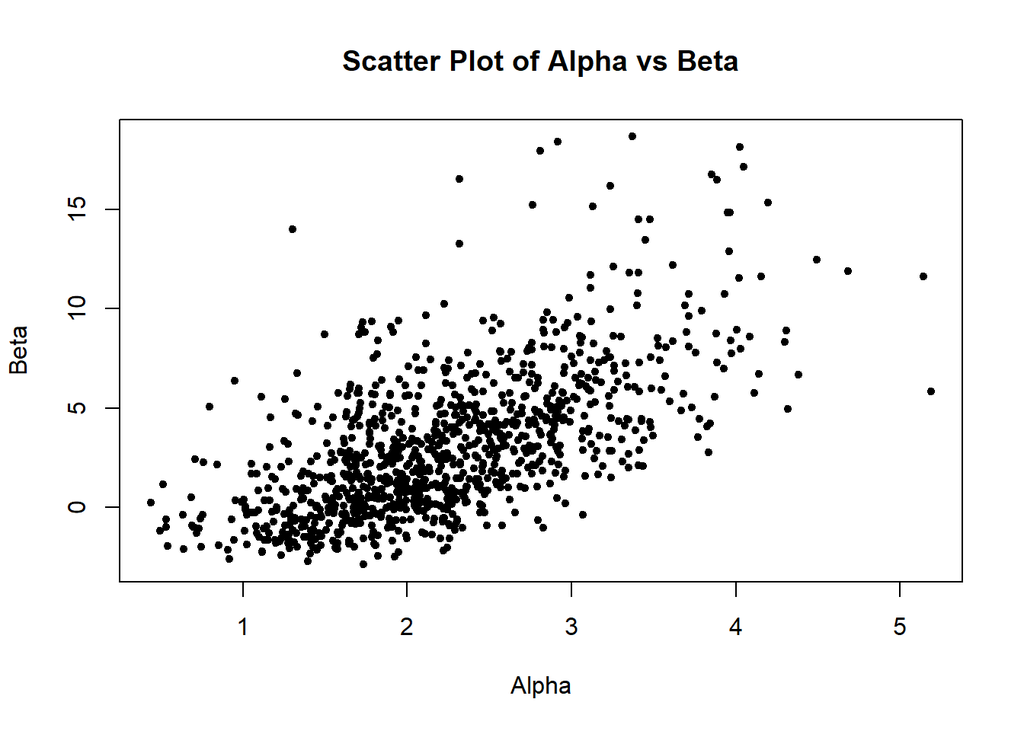

```r
#marginal posterior of alpha by summing over beta
p_alpha_y <- rowSums(N.Post)  # Sum over rows to marginalize over beta
p_alpha_y <- p_alpha_y / sum(p_alpha_y)

# Function to sample alpha^s using inverse CDF method
sample_alpha <- function(p_alpha_y, alpha_values) {
  r <- runif(1)
  cumulative_prob <- cumsum(p_alpha_y)
  j <- which(cumulative_prob >= r)[1]
  return(alpha_values[j])
}

alpha_values <- seq(-2, 8, length.out=L.grid)
alpha_samples <- replicate(1000,sample_alpha(p_alpha_y,alpha_values))
beta_values <- seq(-10, 20, length.out = L.grid)

# Function to sample beta^s given alpha^s using inverse CDF method
sample_beta <- function(alpha_sample, alpha_values, Post) {

  alpha_index <- which.min(abs(alpha_values - alpha_sample))

  p_beta_given_alpha <- Post[alpha_index,]

  p_beta_given_alpha <- p_beta_given_alpha / sum(p_beta_given_alpha, na.rm = TRUE)

  # Draw a sample for beta using inverse CDF method
  r <- runif(1)
  cumulative_prob <- cumsum(p_beta_given_alpha)
  j <- which(cumulative_prob >= r)[1]  #
  return(beta_values[j])
}

# sample 1000 pairs of (alpha^s, beta^s)

beta_samples <- sapply(alpha_samples, sample_beta, alpha_values = alpha_values, Post = N.Post)

alpha_spacing <- alpha_values[2] - alpha_values[1]
beta_spacing <- beta_values[2] - beta_values[1]

# Add uniform jitter to each sample

alpha_samples_continuous <- alpha_samples + runif(length(alpha_samples), -alpha_spacing / 2, alpha_spacing / 2)
beta_samples_continuous <- beta_samples + runif(length(beta_samples), -beta_spacing / 2, beta_spacing / 2)

plot(alpha_samples_continuous, beta_samples_continuous,
     xlab = "Alpha", ylab = "Beta", main = "Scatter Plot of Alpha vs Beta",
     pch = 20)
```

*2 Draw a 1000 random draws ($α^s$, $β^s$) from the joint posterior following an alternative method. Make a scatter plot. It should look like Fig 3.3 (b)*

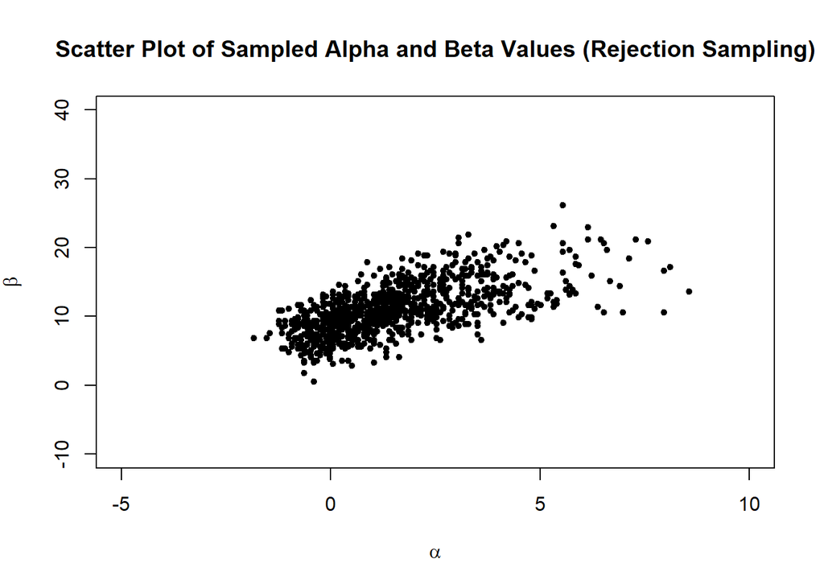

```r
alpha <- seq(-5, 10, length.out = L.grid)
beta <- seq(-10, 40, length.out = L.grid)

alpha_vals <- rep(alpha, each = L.grid)
beta_vals <- rep(beta, times = L.grid)
flat_posterior <- as.vector(N.Post)
flat_posterior[is.na(flat_posterior)] <- 0

flat_posterior <- flat_posterior / sum(flat_posterior)

n_samples <- 1000
sample_indices <- sample(1:length(flat_posterior), size = n_samples, replace = TRUE, prob = flat_posterior)
alpha_samples <- alpha_vals[sample_indices]
beta_samples <- beta_vals[sample_indices]

plot(alpha_samples, beta_samples, xlab = expression(alpha), ylab = expression(beta),
     main = "Scatter Plot of Sampled Alpha and Beta Values (Rejection Sampling)", pch = 20, col = "black",
     xlim = c(-5, 10), ylim = c(-10, 40))
```

*3. Compare the results*

Let’s take a side by side look at the scatterplot.

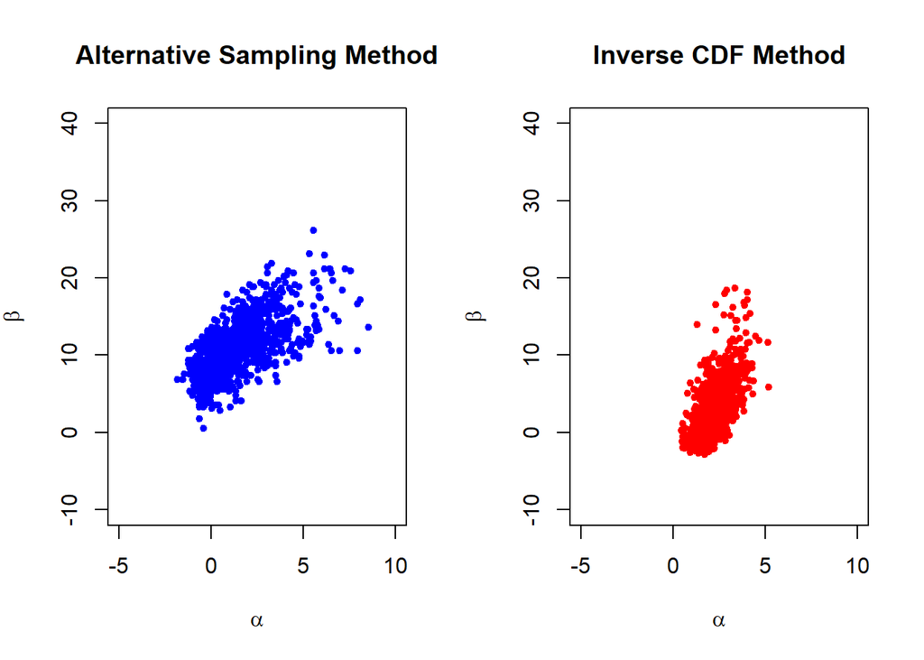

```r
par(mfrow = c(1, 2))

plot(alpha_samples, beta_samples,
     xlab = expression(alpha), ylab = expression(beta), main = "Alternative Sampling Method",
     pch = 20, col = "blue", xlim = c(-5, 10), ylim = c(-10, 40))

plot(alpha_samples_continuous, beta_samples_continuous,
     xlab = expression(alpha), ylab = expression(beta), main = "Inverse CDF Method",
     pch = 20, col ="red", xlim = c(-5, 10), ylim = c(-10, 40))
```

```r
par(mfrow = c(1, 1))
```

```r
# Summary statistics comparison
cat("Summary Statistics for Alternative Sampling Method:\n")
```

```
## Summary Statistics for Alternative Sampling Method:
```

```r
cat("Alpha - Mean:", mean(alpha_samples), "SD:", sd(alpha_samples), "\n")
```

```
## Alpha - Mean: 1.465528 SD: 1.720375
```

```r
cat("Beta - Mean:", mean(beta_samples), "SD:", sd(beta_samples), "\n\n")
```

```
## Beta - Mean: 10.96432 SD: 3.559663
```

```r
cat("Summary Statistics for Inverse CDF Method:\n")
```

```
## Summary Statistics for Inverse CDF Method:
```

```r
cat("Alpha - Mean:", mean(alpha_samples_continuous), "SD:", sd(alpha_samples_continuous), "\n")
```

```
## Alpha - Mean: 2.230017 SD: 0.7493949
```

```r
cat("Beta - Mean:", mean(beta_samples_continuous), "SD:", sd(beta_samples_continuous), "\n")
```

```
## Beta - Mean: 3.078021 SD: 3.586646
```

*4. For both samples, calculate the posterior distribution of LD50 as discussed in BDA3, page 77.*

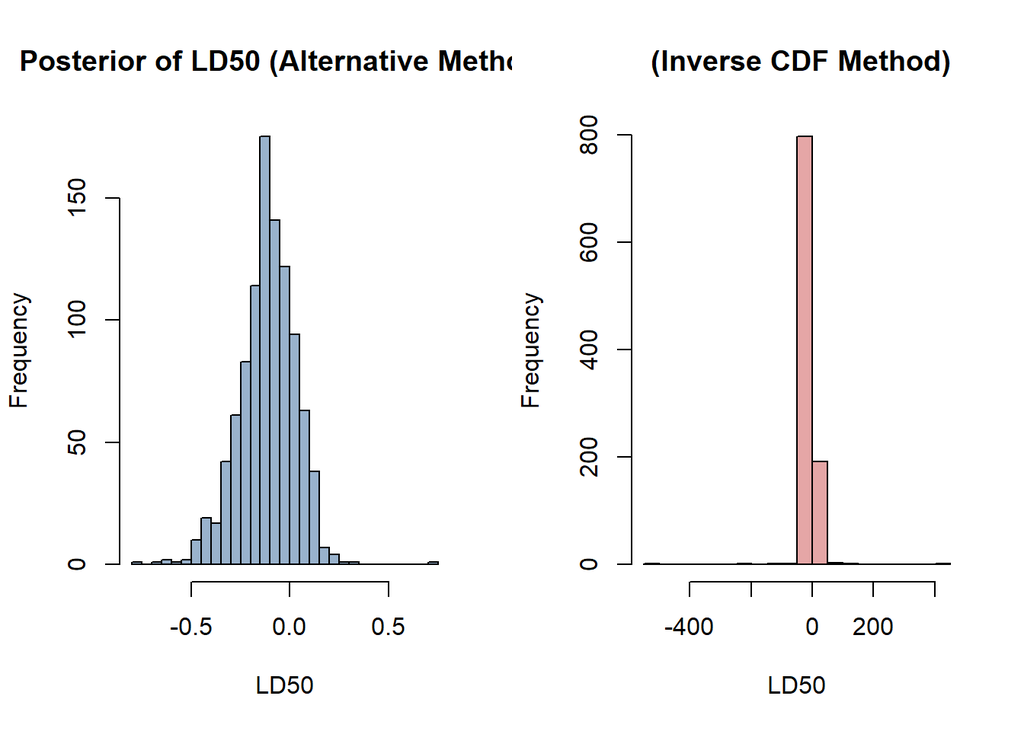

```r
ld50_rejection <- -alpha_samples / beta_samples
ld50_inverse_cdf <- -alpha_samples_continuous / beta_samples_continuous
par(mfrow = c(1, 2))
hist(ld50_rejection, breaks = 30, main = "Posterior of LD50 (Alternative Method)",
     xlab = "LD50", col = rgb(0.2, 0.4, 0.6, 0.5))
hist(ld50_inverse_cdf, breaks = 30, main = " (Inverse CDF Method)",
     xlab = "LD50", col = rgb(0.8, 0.3, 0.3, 0.5))
```

```r
par(mfrow = c(1, 1))
```

```r
# Summary statistics for LD50
cat("Summary Statistics for LD50 (Alternative Sampling Method):\n")
```

```
## Summary Statistics for LD50 (Alternative Sampling Method):
```

```r
cat("Mean:", mean(ld50_rejection), "SD:", sd(ld50_rejection), "\n\n")
```

```
## Mean: -0.1134685 SD: 0.1421168
```

```r
cat("Summary Statistics for LD50 (Inverse CDF Method):\n")
```

```
## Summary Statistics for LD50 (Inverse CDF Method):
```

```r
cat("Mean:", mean(ld50_inverse_cdf), "SD:", sd(ld50_inverse_cdf), "\n")
```

```
## Mean: -1.028123 SD: 24.54301
```

*5. Computation: in the bioassay example, replace the uniform prior density by a joint normal prior distribution on (α, β), with α ∼ N(0, 22), β ∼ N(10, 102), and corr(α, β)=0.5. (a) Repeat all the computations and plots of Section 3.7 with this new prior distribution*

Part a:

Model Specification Observation:

$$y_i \mid \theta_i \sim \text{Binomial}(n_i, \theta_i)$$

$$\text{Logit}(\theta_i) = \alpha + \beta x_i$$

$$\alpha \sim \text{Normal}(0, 2^2)$$

$$\beta \sim \text{Normal}(10, 10^2)$$

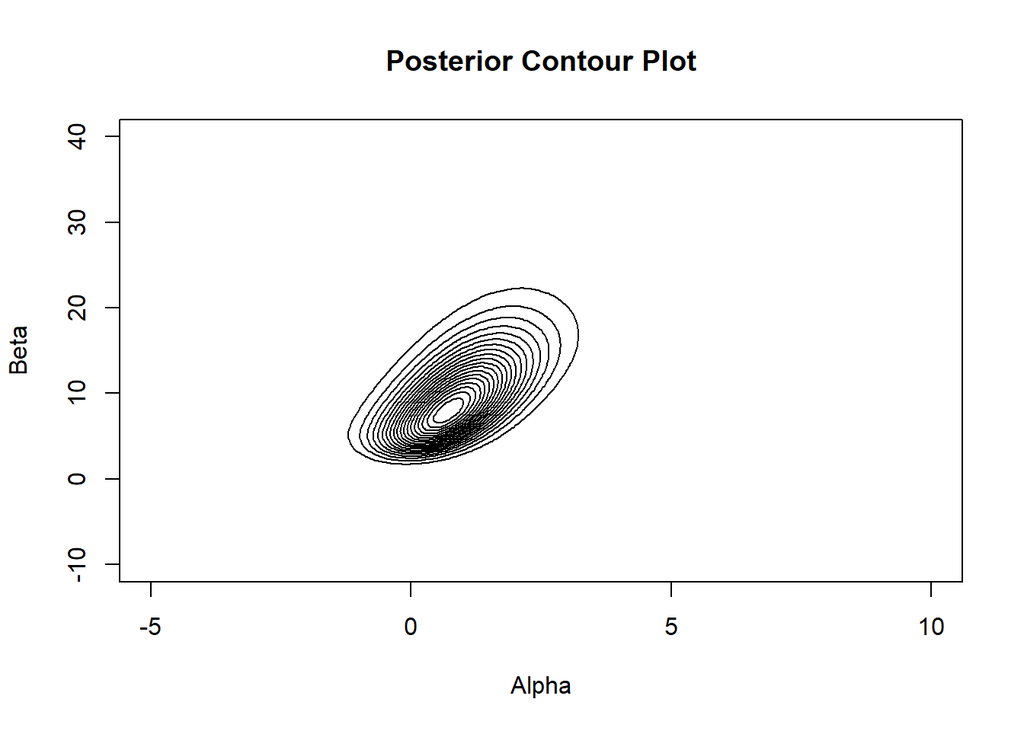

```r
library(MASS)
mu <- c(0, 10)
Sigma <- matrix(c(4, 10, 10, 100), nrow = 2)
Sigma_inv <- solve(Sigma)
log_prior_const <- -0.5 * log(2 * pi * det(Sigma))

post.log <- function(a, b, Y, N, X) {
  # Computing log-likelihood
  l.log <- 0
  for (i in 1:length(X)) {
    prob <- plogis(a + b * X[i])
    l.log <- l.log + Y[i] * log(prob) + (N[i] - Y[i]) * log(1 - prob)
  }

  # Computing log-prior
  theta <- c(a, b)
  log_prior <- log_prior_const - 0.5 * t(theta - mu) %*% Sigma_inv %*% (theta - mu)
    # Combining log-likelihood and log-prior
  return(l.log + log_prior)
}
L.grid <- 200
alpha <- seq(-5, 10, length.out = L.grid)
beta <- seq(-10, 40, length.out = L.grid)

Post <- matrix(NA, L.grid, L.grid)
for (i in 1:L.grid) {
  for (j in 1:L.grid) {
    Post[i, j] <- post.log(alpha[i], beta[j], Y, N, X)
  }
}
Post <- exp(Post - max(Post, na.rm = TRUE))
lev <- seq(0.05, 0.95, by = 0.05)
contour(alpha, beta, Post, levels = lev, drawlabels = FALSE,
        xlab = "Alpha", ylab = "Beta", main = "Posterior Contour Plot")
```

```r
base = (alpha[2]-alpha[1])*(beta[2]-beta[1])
base
```

```
## [1] 0.01893892
```

```r
sum(Post)
```

```
## [1] NaN
```

```r
sum(Post, na.rm = TRUE)
```

```
## [1] 1000.549
```

```r
Post[is.nan(Post)] <- 0
sum(Post)
```

```
## [1] 1000.549
```

```r
N.Post <- Post/sum(Post*base, na.rm = TRUE)
sum(N.Post*base)
```

```
## [1] 1
```

Below I am drawing a 1000 random draws (αs, βs) from the new joint posterior (with a new prior distribution specified in part a) following the procedure outlined in the book, i.e., the inverse cdf method. And I will make a scatter plot.

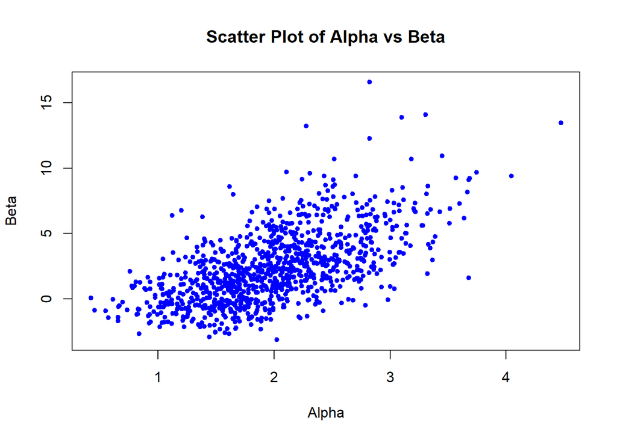

```r
p_alpha_y <- rowSums(N.Post)
p_alpha_y <- p_alpha_y / sum(p_alpha_y)
sample_alpha <- function(p_alpha_y, alpha_values) {
  r <- runif(1)
  cumulative_prob <- cumsum(p_alpha_y)
  j <- which(cumulative_prob >= r)[1]
  return(alpha_values[j])
}

alpha_values <- seq(-2, 8, length.out=L.grid)
alpha_samples <- replicate(1000, sample_alpha(p_alpha_y, alpha_values))
beta_values <- seq(-10, 20, length.out = L.grid)

sample_beta <- function(alpha_sample, alpha_values, Post) {

  alpha_index <- which.min(abs(alpha_values - alpha_sample))

  p_beta_given_alpha <- Post[alpha_index, ]
   p_beta_given_alpha <- p_beta_given_alpha / sum(p_beta_given_alpha, na.rm = TRUE)
  r <- runif(1)
  cumulative_prob <- cumsum(p_beta_given_alpha)
  j <- which(cumulative_prob >= r)[1]
  return(beta_values[j])
}

beta_samples <- sapply(alpha_samples, sample_beta, alpha_values = alpha_values, Post = N.Post)

alpha_spacing <- alpha_values[2] - alpha_values[1]
beta_spacing <- beta_values[2] - beta_values[1]

alpha_samples_continuous <- alpha_samples + runif(length(alpha_samples), -alpha_spacing / 2, alpha_spacing / 2)
beta_samples_continuous <- beta_samples + runif(length(beta_samples), -beta_spacing / 2, beta_spacing / 2)

plot(alpha_samples_continuous, beta_samples_continuous,
     xlab = "Alpha", ylab = "Beta", main = "Scatter Plot of Alpha vs Beta",
     pch = 20, col = "blue")
```

*(b) Check that your contour plot and scatterplot look like a compromise between the prior distribution and the likelihood (as displayed in Figure 3.3)*

part b

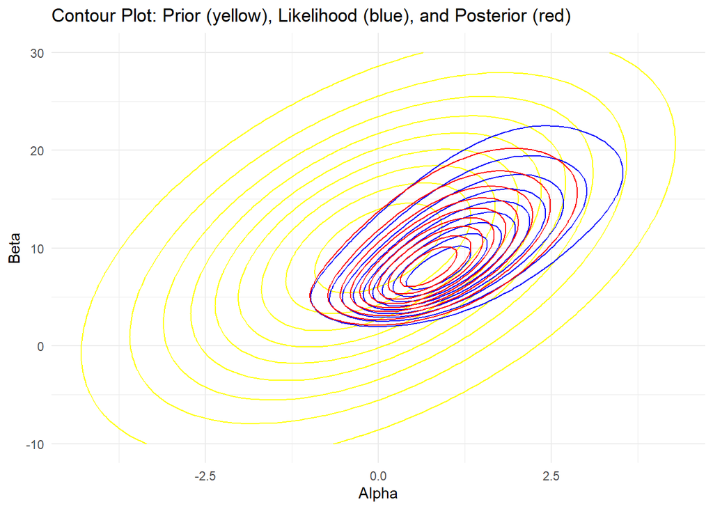

```r
library(ggplot2)

L.grid <- 100
alpha <- seq(-5, 8, length.out = L.grid)
beta <- seq(-10, 30, length.out = L.grid)
grid <- expand.grid(alpha = alpha, beta = beta)

prior_only <- function(a, b) {
  theta <- c(a, b)
  log_prior <- -0.5 * t(theta - mu) %*% Sigma_inv %*% (theta - mu)
  return(exp(log_prior))
}

likelihood_only <- function(a, b, Y, N, X) {
  l.log <- 0
  for (i in 1:length(X)) {
    prob <- plogis(a + b * X[i])
    l.log <- l.log + Y[i] * log(prob) + (N[i] - Y[i]) * log(1 - prob)
  }
  return(exp(l.log))
}

posterior <- function(a, b) {
  log_post <- post.log(a, b, Y, N, X)
  return(exp(log_post))
}

grid$Prior <- apply(grid, 1, function(row) prior_only(row["alpha"], row["beta"]))
grid$Likelihood <- apply(grid, 1, function(row) likelihood_only(row["alpha"], row["beta"], Y, N, X))
grid$Posterior <- apply(grid, 1, function(row) posterior(row["alpha"], row["beta"]))

grid$Prior <- grid$Prior / max(grid$Prior)
grid$Likelihood <- grid$Likelihood / max(grid$Likelihood)
grid$Posterior <- grid$Posterior / max(grid$Posterior)

ggplot(grid, aes(x = alpha, y = beta)) +
  geom_contour(aes(z = Prior), color = "yellow") +
  geom_contour(aes(z = Likelihood), color = "blue") +
  geom_contour(aes(z = Posterior), color = "red") +
  labs(title = "Contour Plot: Prior (yellow), Likelihood (blue), and Posterior (red)",
       x = "Alpha", y = "Beta") +
  theme_minimal()
```

We can see that the red joint is a compromise of the yellow prior and blue data likelihoods.

*(c) Discuss the effect of this hypothetical prior information on the conclusions in the applied context.*

The prior doesn’t change the posterior mode much but reduces the uncertainty in the positive area.

*Repeat problems 1 - 4*

I have already executed 1000 draws using Inverse CDF method. I also made a scatterplot Please look at part (a) of question 5.

*Repeating problem 2*

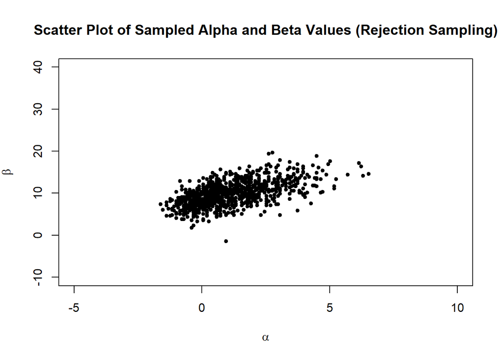

```r
set.seed(123)
mu <- c(0, 10)
Sigma <- matrix(c(4, 10, 10, 100), nrow = 2)
Sigma_inv <- solve(Sigma)
log_prior_const <- -0.5 * log(2 * pi * det(Sigma))

post.log <- function(a, b, Y, N, X) {
  # Computing log-likelihood
  l.log <- 0
  for (i in 1:length(X)) {
    prob <- plogis(a + b * X[i])
    l.log <- l.log + Y[i] * log(prob) + (N[i] - Y[i]) * log(1 - prob)
  }

  # Computing log-prior
  theta <- c(a, b)
  log_prior <- log_prior_const - 0.5 * t(theta - mu) %*% Sigma_inv %*% (theta - mu)
    # Combining log-likelihood and log-prior
  return(l.log + log_prior)
}
L.grid <- 200
alpha <- seq(-5, 10, length.out = L.grid)
beta <- seq(-10, 40, length.out = L.grid)

Post <- matrix(NA, L.grid, L.grid)
for (i in 1:L.grid) {
  for (j in 1:L.grid) {
    Post[i, j] <- post.log(alpha[i], beta[j], Y, N, X)
  }
}
Post <- exp(Post - max(Post, na.rm = TRUE))
base = (alpha[2]-alpha[1])*(beta[2]-beta[1])
Post[is.nan(Post)] <- 0
N.Post <- Post/sum(Post*base, na.rm = TRUE)

alpha <- seq(-5, 10, length.out = L.grid)
beta <- seq(-10, 40, length.out = L.grid)

alpha_vals <- rep(alpha, each = L.grid)
beta_vals <- rep(beta, times = L.grid)
flat_posterior <- as.vector(N.Post)
flat_posterior[is.na(flat_posterior)] <- 0

flat_posterior <- flat_posterior / sum(flat_posterior)

n_samples <- 1000
sample_indices <- sample(1:length(flat_posterior), size = n_samples, replace = TRUE, prob = flat_posterior)
alpha_samples <- alpha_vals[sample_indices]
beta_samples <- beta_vals[sample_indices]

plot(alpha_samples, beta_samples, xlab = expression(alpha), ylab = expression(beta),
     main = "Scatter Plot of Sampled Alpha and Beta Values (Rejection Sampling)", pch = 20, col = "black",
     xlim = c(-5, 10), ylim = c(-10, 40))
```

*Repeating problem 3*

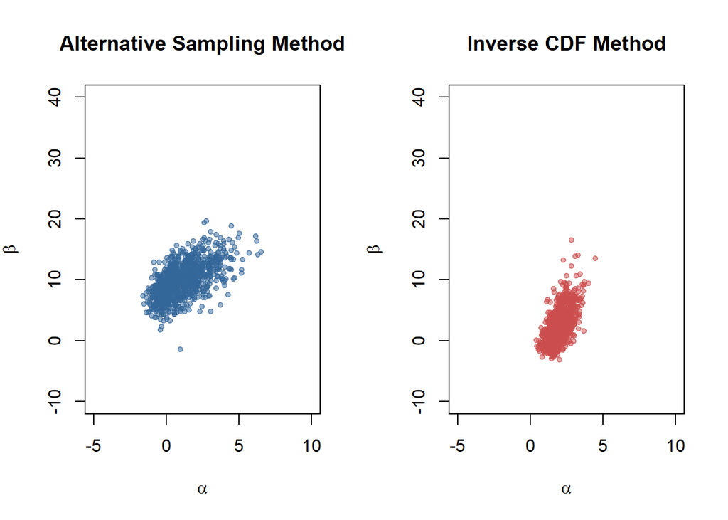

```r
par(mfrow = c(1, 2))
plot(alpha_samples, beta_samples,
     xlab = expression(alpha), ylab = expression(beta), main = "Alternative Sampling Method",
     pch = 20, col = rgb(0.2, 0.4, 0.6, 0.5), xlim = c(-5, 10), ylim = c(-10, 40))
plot(alpha_samples_continuous, beta_samples_continuous,
     xlab = expression(alpha), ylab = expression(beta), main = "Inverse CDF Method",
     pch = 20, col = rgb(0.8, 0.3, 0.3, 0.5), xlim = c(-5, 10), ylim = c(-10, 40))
```

```r
par(mfrow = c(1, 1))
```

```r
# Summary statistics comparison
cat("Summary Statistics for Rejection Sampling:\n")
```

```
## Summary Statistics for Rejection Sampling:
```

```r
cat("Alpha - Mean:", mean(alpha_samples), "SD:", sd(alpha_samples), "\n")
```

```
## Alpha - Mean: 1.119472 SD: 1.374891
```

```r
cat("Beta - Mean:", mean(beta_samples), "SD:", sd(beta_samples), "\n\n")
```

```
## Beta - Mean: 9.920854 SD: 2.834847
```

```r
cat("Summary Statistics for Inverse CDF Method:\n")
```

```
## Summary Statistics for Inverse CDF Method:
```

```r
cat("Alpha - Mean:", mean(alpha_samples_continuous), "SD:", sd(alpha_samples_continuous), "\n")
```

```
## Alpha - Mean: 1.986056 SD: 0.6074496
```

```r
cat("Beta - Mean:", mean(beta_samples_continuous), "SD:", sd(beta_samples_continuous), "\n")
```

```
## Beta - Mean: 2.360302 SD: 2.750671
```

*Repeating problem 4*

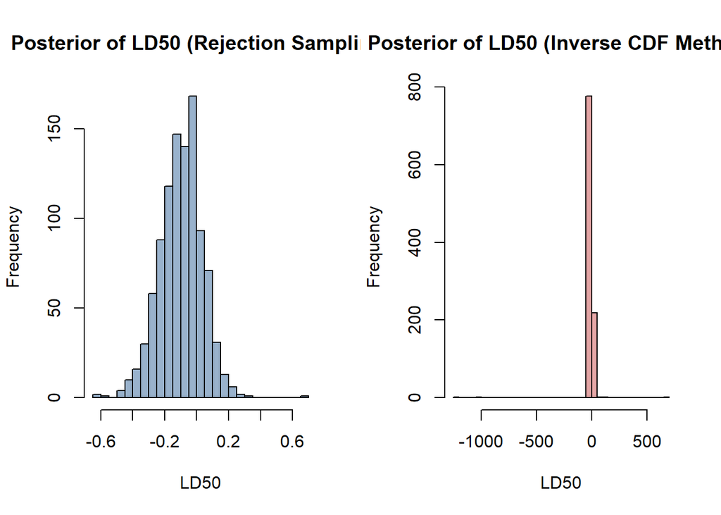

```r
ld50_rejection <- -alpha_samples / beta_samples
ld50_inverse_cdf <- -alpha_samples_continuous / beta_samples_continuous

par(mfrow = c(1, 2))
hist(ld50_rejection, breaks = 30, main = "Posterior of LD50 (Rejection Sampling)",
     xlab = "LD50", col = rgb(0.2, 0.4, 0.6, 0.5))

hist(ld50_inverse_cdf, breaks = 30, main = "Posterior of LD50 (Inverse CDF Method)",
     xlab = "LD50", col = rgb(0.8, 0.3, 0.3, 0.5))
```

```r
par(mfrow = c(1, 1))
```

```r
cat("Summary Statistics for LD50 (Rejection Sampling):\n")
```

```
## Summary Statistics for LD50 (Rejection Sampling):
```

```r
cat("Mean:", mean(ld50_rejection), "SD:", sd(ld50_rejection), "\n\n")
```

```
## Mean: -0.09687702 SD: 0.1328407
```

```r
cat("Summary Statistics for LD50 (Inverse CDF Method):\n")
```

```
## Summary Statistics for LD50 (Inverse CDF Method):
```

```r
cat("Mean:", mean(ld50_inverse_cdf), "SD:", sd(ld50_inverse_cdf), "\n")
```

```
## Mean: -1.317552 SD: 55.26015
```